# Machine Learning Assignment

Levi Brackman

February 22, 2016

Using devices such as Jawbone Up, Nike FuelBand, and Fitbit it is now possible to collect a large amount of data about personal activity relatively inexpensively. These type of devices are part of the quantified self movement – a group of enthusiasts who take measurements about themselves regularly to improve their health, to find patterns in their behavior, or because they are tech geeks. One thing that people regularly do is quantify how much of a particular activity they do, but they rarely quantify how well they do it. In this project, your goal will be to use data from accelerometers on the belt, forearm, arm, and dumbell of 6 participants. They were asked to perform barbell lifts correctly and incorrectly in 5 different ways. More information is available from the website here: http://groupware.les.inf.puc-rio.br/har (see the section on the Weight Lifting Exercise Dataset).

```r
#Load the training and testing dataset. Take a look and see the dimensions
```

```r
training<- read.csv(url("https://d396qusza40orc.cloudfront.net/predmachlearn/pml-training.csv"), na.strings=c("","#DIV/0!","NA"))
#View(training)
testing<- read.csv(url("https://d396qusza40orc.cloudfront.net/predmachlearn/pml-testing.csv"), na.strings=c("","#DIV/0!","NA"))
dim(training); dim(testing)
```

```
## [1] 19622   160
```

```
## [1]  20 160
```

Remove the colunms that are not relevant for predicting such as ID

Dealing with missing data missing data. It truns out that there is so much missing data that we are unable to do imputation using k-nearest neighbours. So instead we remove the veriables with the missing data from the analysis and build models using the veriables (co-veriates) that have full data.

[output not shown]

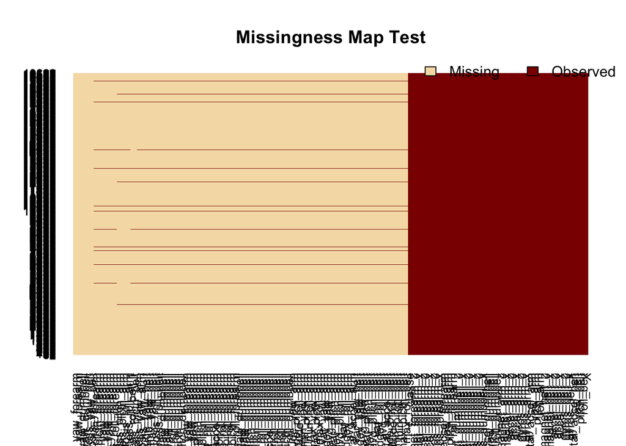

Creat a training and validation set

```
## [1] 13737    53
```

```
## [1] 5885   53
```

```
##
## Call:
##  randomForest(x = x, y = y, mtry = param$mtry, importance = TRUE)
##                Type of random forest: classification
##                      Number of trees: 500
## No. of variables tried at each split: 27
##
##         OOB estimate of  error rate: 0.44%
## Confusion matrix:
##      A    B    C    D    E  class.error
## A 5576    2    1    0    1 0.0007168459
## B   19 3773    5    0    0 0.0063207796
## C    0   11 3401   10    0 0.0061367621
## D    0    0   22 3191    3 0.0077736318
## E    0    1    4    7 3595 0.0033268644
```

```
## Random Forest
##
## 19622 samples
##    52 predictor
##     5 classes: 'A', 'B', 'C', 'D', 'E'
##
## No pre-processing
## Resampling: Cross-Validated (3 fold)
## Summary of sample sizes: 13082, 13080, 13082
## Resampling results across tuning parameters:
##
##   mtry  Accuracy   Kappa      Accuracy SD  Kappa SD
##    2    0.9923556  0.9903291  0.002156821  0.002729366
##   27    0.9927634  0.9908458  0.001988362  0.002515823
##   52    0.9863932  0.9827867  0.003066551  0.003878782
##
## Accuracy was used to select the optimal model using  the largest value.
## The final value used for the model was mtry = 27.
```

```
##                          A          B         C         D         E
## roll_belt        75.269727  89.342003 88.270100 76.897388 98.511158
## pitch_belt       27.284153 100.000000 63.656186 51.154930 41.589081
## yaw_belt         59.699235  67.239037 71.350799 79.107163 47.566395
## total_accel_belt  2.209509   8.473578  7.518254  5.239483  6.322352
## gyros_belt_x     29.435792  10.884973 17.847330  6.613614 12.406563
## gyros_belt_y      1.282396  11.830368 10.163533  5.145252 13.113357
## gyros_belt_z     24.321360  30.611629 30.622295 21.149837 38.940627
## accel_belt_x      1.765322   8.154252  6.887597  2.414164  5.885206
## accel_belt_y      0.000000   7.973635  5.325105  6.488268  1.807148
## accel_belt_z     13.218224  18.042985 19.851478 19.400673 13.733202
```

```
## Confusion Matrix and Statistics
##
##           Reference
## Prediction    A    B    C    D    E
##          A 1674    0    0    0    0
##          B    0 1139    0    0    0
##          C    0    0 1026    0    0
##          D    0    0    0  964    0
##          E    0    0    0    0 1082
##
## Overall Statistics
##
##                Accuracy : 1
##                  95% CI : (0.9994, 1)
##     No Information Rate : 0.2845
##     P-Value [Acc > NIR] : < 2.2e-16
##
##                   Kappa : 1
##  Mcnemar's Test P-Value : NA
##
## Statistics by Class:
##
##                      Class: A Class: B Class: C Class: D Class: E
## Sensitivity            1.0000   1.0000   1.0000   1.0000   1.0000
## Specificity            1.0000   1.0000   1.0000   1.0000   1.0000
## Pos Pred Value         1.0000   1.0000   1.0000   1.0000   1.0000
## Neg Pred Value         1.0000   1.0000   1.0000   1.0000   1.0000
## Prevalence             0.2845   0.1935   0.1743   0.1638   0.1839
## Detection Rate         0.2845   0.1935   0.1743   0.1638   0.1839
## Detection Prevalence   0.2845   0.1935   0.1743   0.1638   0.1839
## Balanced Accuracy      1.0000   1.0000   1.0000   1.0000   1.0000
```

Create a Decision Trees Model. When tested on the validation set we only get a 49% accuracy levle. This is significantly lower than the Random Forest model.

```
## n= 19622
##
## node), split, n, loss, yval, (yprob)
##       * denotes terminal node
##
##  1) root 19622 14042 A (0.28 0.19 0.17 0.16 0.18)
##    2) roll_belt< 130.5 17977 12411 A (0.31 0.21 0.19 0.18 0.11)
##      4) pitch_forearm< -33.95 1578    10 A (0.99 0.0063 0 0 0) *
##      5) pitch_forearm>=-33.95 16399 12401 A (0.24 0.23 0.21 0.2 0.12)
##       10) magnet_dumbbell_y< 439.5 13870  9953 A (0.28 0.18 0.24 0.19 0.11)
##         20) roll_forearm< 123.5 8643  5131 A (0.41 0.18 0.18 0.17 0.061) *
##         21) roll_forearm>=123.5 5227  3500 C (0.077 0.18 0.33 0.23 0.18) *
##       11) magnet_dumbbell_y>=439.5 2529  1243 B (0.032 0.51 0.043 0.22 0.19) *
##    3) roll_belt>=130.5 1645    14 E (0.0085 0 0 0 0.99) *
```

```
## CART
##
## 19622 samples
##    52 predictor
##     5 classes: 'A', 'B', 'C', 'D', 'E'
##
## No pre-processing
## Resampling: Bootstrapped (25 reps)
## Summary of sample sizes: 19622, 19622, 19622, 19622, 19622, 19622, ...
## Resampling results across tuning parameters:
##
##   cp          Accuracy   Kappa       Accuracy SD  Kappa SD
##   0.03567868  0.5044168  0.35363084  0.03687507   0.05772535
##   0.05998671  0.4219773  0.21839942  0.06380335   0.10678247
##   0.11515454  0.3298996  0.06879926  0.03843689   0.06227674
##
## Accuracy was used to select the optimal model using  the largest value.
## The final value used for the model was cp = 0.03567868.
```

```
##  [1]  26.33018  43.02061  15.60461  27.09355  40.79762  49.50841  36.37244
##  [8] 100.00000  15.27725  70.35767
```

```
## Confusion Matrix and Statistics
##
##           Reference
## Prediction    A    B    C    D    E
##          A 1517  497  473  412  156
##          B   21  355   39  172  159
##          C  131  287  514  380  287
##          D    0    0    0    0    0
##          E    5    0    0    0  480
##
## Overall Statistics
##
##                Accuracy : 0.487
##                  95% CI : (0.4742, 0.4999)
##     No Information Rate : 0.2845
##     P-Value [Acc > NIR] : < 2.2e-16
##
##                   Kappa : 0.3297
##  Mcnemar's Test P-Value : NA
##
## Statistics by Class:
##
##                      Class: A Class: B Class: C Class: D Class: E
## Sensitivity            0.9062  0.31168  0.50097   0.0000  0.44362
## Specificity            0.6348  0.91761  0.77670   1.0000  0.99896
## Pos Pred Value         0.4966  0.47587  0.32145      NaN  0.98969
## Neg Pred Value         0.9445  0.84744  0.88054   0.8362  0.88852
## Prevalence             0.2845  0.19354  0.17434   0.1638  0.18386
## Detection Rate         0.2578  0.06032  0.08734   0.0000  0.08156
## Detection Prevalence   0.5191  0.12676  0.27171   0.0000  0.08241
## Balanced Accuracy      0.7705  0.61465  0.63884   0.5000  0.72129
```

Creat a Boosted Trees Model. Boosted Trees are significantly better than a regular decision tree model with 97% accuracy rate.

```
## A gradient boosted model with multinomial loss function.
## 150 iterations were performed.
## There were 52 predictors of which 42 had non-zero influence.
```

```
## Stochastic Gradient Boosting
##
## 19622 samples
##    52 predictor
##     5 classes: 'A', 'B', 'C', 'D', 'E'
##
## No pre-processing
## Resampling: Bootstrapped (25 reps)
## Summary of sample sizes: 19622, 19622, 19622, 19622, 19622, 19622, ...
## Resampling results across tuning parameters:
##
##   interaction.depth  n.trees  Accuracy   Kappa      Accuracy SD
##   1                   50      0.7495312  0.6823611  0.007862554
##   1                  100      0.8173294  0.7687573  0.004355343
##   1                  150      0.8509042  0.8112842  0.004891224
##   2                   50      0.8527936  0.8134596  0.004322389
##   2                  100      0.9049576  0.8797078  0.003713355
##   2                  150      0.9305021  0.9120421  0.003691800
##   3                   50      0.8955238  0.8677281  0.004888657
##   3                  100      0.9412102  0.9255994  0.003534972
##   3                  150      0.9599718  0.9493523  0.002605752
##   Kappa SD
##   0.010029467
##   0.005432428
##   0.006196050
##   0.005439125
##   0.004707265
##   0.004679887
##   0.006187964
##   0.004483011
##   0.003293786
##
## Tuning parameter 'shrinkage' was held constant at a value of 0.1
##
## Tuning parameter 'n.minobsinnode' was held constant at a value of 10
## Accuracy was used to select the optimal model using  the largest value.
## The final values used for the model were n.trees = 150,
##  interaction.depth = 3, shrinkage = 0.1 and n.minobsinnode = 10.
```

```
##  [1]  26.33018  43.02061  15.60461  27.09355  40.79762  49.50841  36.37244
##  [8] 100.00000  15.27725  70.35767
```

```
## Confusion Matrix and Statistics
##
##           Reference
## Prediction    A    B    C    D    E
##          A 1665   20    0    1    1
##          B    6 1104   24    4   14
##          C    3   14  990   26    8
##          D    0    1   10  930   14
##          E    0    0    2    3 1045
##
## Overall Statistics
##
##                Accuracy : 0.9743
##                  95% CI : (0.97, 0.9782)
##     No Information Rate : 0.2845
##     P-Value [Acc > NIR] : < 2.2e-16
##
##                   Kappa : 0.9675
##  Mcnemar's Test P-Value : 4.434e-07
##
## Statistics by Class:
##
##                      Class: A Class: B Class: C Class: D Class: E
## Sensitivity            0.9946   0.9693   0.9649   0.9647   0.9658
## Specificity            0.9948   0.9899   0.9895   0.9949   0.9990
## Pos Pred Value         0.9870   0.9583   0.9510   0.9738   0.9952
## Neg Pred Value         0.9979   0.9926   0.9926   0.9931   0.9923
## Prevalence             0.2845   0.1935   0.1743   0.1638   0.1839
## Detection Rate         0.2829   0.1876   0.1682   0.1580   0.1776
## Detection Prevalence   0.2867   0.1958   0.1769   0.1623   0.1784
## Balanced Accuracy      0.9947   0.9796   0.9772   0.9798   0.9824
```

Create a Linear Discriminant Analysis (LDA) Model. LDA is worse than the boosted model giving us only a 71% accuracy rate on the validation set.

```
## Call:
## lda(x, grouping = y)
##
## Prior probabilities of groups:
##         A         B         C         D         E
## 0.2843747 0.1935073 0.1743961 0.1638977 0.1838243
##
## Group means:
##   roll_belt  pitch_belt   yaw_belt total_accel_belt gyros_belt_x
## A  59.34989  0.35583871 -12.033455         10.67814 -0.004922939
## B  65.16313 -0.01914669 -13.291030         11.13853 -0.004824862
## C  64.81424 -1.04698714  -7.379407         11.18381 -0.014921099
## D  60.85452  1.81800684 -17.864089         11.22917 -0.014732587
## E  74.21647  0.50276130  -5.419947         12.67397  0.009564735
##   gyros_belt_y gyros_belt_z accel_belt_x accel_belt_y accel_belt_z
## A   0.04048566   -0.1213746    -6.261290     28.94265    -62.68387
## B   0.04253095   -0.1347748    -4.934422     31.97603    -73.60047
## C   0.03949445   -0.1350994    -4.048802     31.11748    -71.07949
## D   0.03633396   -0.1365641    -8.279851     30.46300    -69.24192
## E   0.03808983   -0.1305517    -4.331023     28.92515    -91.28888
##   magnet_belt_x magnet_belt_y magnet_belt_z   roll_arm  pitch_arm
## A      57.82975      602.1978     -337.9289 -0.5660538   3.383511
## B      49.21991      599.3790     -336.6987 32.0088491  -6.560208
## C      57.21186      599.9357     -337.3501 24.9816949  -1.635038
## D      48.67413      594.2848     -340.6213 22.6384359 -10.460211
## E      63.51733      568.0133     -378.4549 20.2917300 -12.539767
##      yaw_arm total_accel_arm gyros_arm_x gyros_arm_y gyros_arm_z
## A -11.755769        27.37849  0.02743548  -0.2210914   0.2643136
## B   7.903139        26.53095  0.02274954  -0.2859679   0.2659310
## C   3.935570        24.30216  0.10156341  -0.2638574   0.2744711
## D   5.151536        23.39521  0.03544776  -0.2527550   0.2652208
## E  -1.826180        24.56834  0.03833102  -0.2797754   0.2802717
##   accel_arm_x accel_arm_y accel_arm_z magnet_arm_x magnet_arm_y
## A  -132.15789    47.17778   -75.36254    -19.14964    235.60789
## B   -42.32763    25.42218   -95.62813    234.74032    130.17408
## C   -78.04880    41.00701   -53.60959    155.86937    190.20134
## D    15.78638    25.01710   -47.83986    397.18252     97.03545
## E   -18.73025    16.37344   -76.80704    323.48489     83.48461
##   magnet_arm_z roll_dumbbell pitch_dumbbell yaw_dumbbell
## A     410.6249      21.58705     -18.917893     1.496744
```

[output cut: 137 more lines]

```
## yaw_forearm           1.144113e-03
## total_accel_forearm   2.577901e-03
## gyros_forearm_x       1.373483e-01
## gyros_forearm_y       5.898712e-03
## gyros_forearm_z      -3.601500e-02
## accel_forearm_x       3.871118e-03
## accel_forearm_y      -2.012050e-03
## accel_forearm_z      -4.542622e-03
## magnet_forearm_x     -1.166947e-03
## magnet_forearm_y      3.283250e-04
## magnet_forearm_z      1.129935e-03
##
## Proportion of trace:
##    LD1    LD2    LD3    LD4
## 0.4903 0.2411 0.1546 0.1140
```

```
## Linear Discriminant Analysis
##
## 19622 samples
##    52 predictor
##     5 classes: 'A', 'B', 'C', 'D', 'E'
##
## No pre-processing
## Resampling: Bootstrapped (25 reps)
## Summary of sample sizes: 19622, 19622, 19622, 19622, 19622, 19622, ...
## Resampling results
##
##   Accuracy   Kappa      Accuracy SD  Kappa SD
##   0.7002734  0.6205891  0.005402671  0.006547187
##
##
```

```
## Confusion Matrix and Statistics
##
##           Reference
## Prediction    A    B    C    D    E
##          A 1382  158  101   54   44
##          B   31  725  101   41  178
##          C  137  157  686  101   92
##          D  117   50  121  732  111
##          E    7   49   17   36  657
##
## Overall Statistics
##
##                Accuracy : 0.7106
##                  95% CI : (0.6988, 0.7222)
##     No Information Rate : 0.2845
##     P-Value [Acc > NIR] : < 2.2e-16
##
##                   Kappa : 0.6339
##  Mcnemar's Test P-Value : < 2.2e-16
##
## Statistics by Class:
##
##                      Class: A Class: B Class: C Class: D Class: E
## Sensitivity            0.8256   0.6365   0.6686   0.7593   0.6072
## Specificity            0.9152   0.9260   0.8998   0.9189   0.9773
## Pos Pred Value         0.7947   0.6738   0.5848   0.6472   0.8577
## Neg Pred Value         0.9296   0.9139   0.9278   0.9512   0.9170
## Prevalence             0.2845   0.1935   0.1743   0.1638   0.1839
## Detection Rate         0.2348   0.1232   0.1166   0.1244   0.1116
## Detection Prevalence   0.2955   0.1828   0.1993   0.1922   0.1302
## Balanced Accuracy      0.8704   0.7813   0.7842   0.8391   0.7923
```

Here we create a table of accuracy measures and as this shows clearly Random Forest gives us the best accuracy rate.

Accuracy rate on training set

```r
accuraciesinsam
```

```
##   Random Forest Decision Trees Boosted Trees Linear Discriminant Analysis
## 1     0.9927634      0.5044168     0.9599718                    0.7002734
```

Accuracy rate on validation set

```r
accuracies
```

```
##          Random Forest Decision Trees Boosted Trees
## Accuracy             1      0.4870008     0.9743415
##          Linear Discriminant Analysis
## Accuracy                    0.7106202
```

```
##                 Random Forest Decision Trees Boosted Trees
## In Sample Error     0.0072366      0.4955832     0.0400282
##                 Linear Discriminant Analysis
## In Sample Error                    0.2997266
```

```
##                     Random Forest Decision Trees Boosted Trees
## Out of Sample Error             0      0.5129992    0.02565845
##                     Linear Discriminant Analysis
## Out of Sample Error                    0.2893798
```

Predict the classe variable of the testing data

```r
ClasseTesting <- predict(modRF, testing)
ClasseTesting
```

```
##  [1] B A B A A E D B A A B C B A E E A B B B
## Levels: A B C D E
```

## Appendix

```r
#Load the training and testing dataset. Take a look and see the dimensions
training<- read.csv(url("https://d396qusza40orc.cloudfront.net/predmachlearn/pml-training.csv"), na.strings=c("","#DIV/0!","NA"))
#View(training)
testing<- read.csv(url("https://d396qusza40orc.cloudfront.net/predmachlearn/pml-testing.csv"), na.strings=c("","#DIV/0!","NA"))
dim(training); dim(testing)
require(dplyr)
#detach("package:dplyr", character.only = TRUE)
#library("dplyr", character.only = TRUE)
training<- select(training, -c(user_name,   raw_timestamp_part_1,   raw_timestamp_part_2,   cvtd_timestamp, new_window, num_window))
testing<- select(testing, -c(user_name, raw_timestamp_part_1,   raw_timestamp_part_2,   cvtd_timestamp, new_window, num_window))
library(Amelia)
missmap(training, main = "Missingness Map Test")
#install.packages("VIM")
#require(VIM)
#install.packages("DMwR")
#require(DMwR)
#training<-knnImputation(training)
#unable to impute missing data so will remove missing data
missing<-colnames(training)[colSums(is.na(training)) > 0]
#dput(as.character(missing))
require(caret)
training<-select(training, -c(kurtosis_roll_belt, kurtosis_picth_belt, kurtosis_yaw_belt,
+  skewness_roll_belt, skewness_roll_belt.1, skewness_yaw_belt,
+  max_roll_belt, max_picth_belt, max_yaw_belt, min_roll_belt,
+  min_pitch_belt, min_yaw_belt, amplitude_roll_belt, amplitude_pitch_belt,
+  amplitude_yaw_belt, var_total_accel_belt, avg_roll_belt,
+  stddev_roll_belt, var_roll_belt, avg_pitch_belt, stddev_pitch_belt,
+  var_pitch_belt, avg_yaw_belt, stddev_yaw_belt, var_yaw_belt,
+  var_accel_arm, avg_roll_arm, stddev_roll_arm, var_roll_arm,
+  avg_pitch_arm, stddev_pitch_arm, var_pitch_arm, avg_yaw_arm,
+  stddev_yaw_arm, var_yaw_arm, kurtosis_roll_arm, kurtosis_picth_arm,
+  kurtosis_yaw_arm, skewness_roll_arm, skewness_pitch_arm,
+  skewness_yaw_arm, max_roll_arm, max_picth_arm, max_yaw_arm,
+  min_roll_arm, min_pitch_arm, min_yaw_arm, amplitude_roll_arm,
+  amplitude_pitch_arm, amplitude_yaw_arm, kurtosis_roll_dumbbell,
+  kurtosis_picth_dumbbell, kurtosis_yaw_dumbbell, skewness_roll_dumbbell,
+  skewness_pitch_dumbbell, skewness_yaw_dumbbell, max_roll_dumbbell,
+  max_picth_dumbbell, max_yaw_dumbbell, min_roll_dumbbell,
+  min_pitch_dumbbell, min_yaw_dumbbell, amplitude_roll_dumbbell,
+  amplitude_pitch_dumbbell, amplitude_yaw_dumbbell, var_accel_dumbbell,
+  avg_roll_dumbbell, stddev_roll_dumbbell, var_roll_dumbbell,
+  avg_pitch_dumbbell, stddev_pitch_dumbbell, var_pitch_dumbbell,
+  avg_yaw_dumbbell, stddev_yaw_dumbbell, var_yaw_dumbbell,
+  kurtosis_roll_forearm, kurtosis_picth_forearm, kurtosis_yaw_forearm,
+  skewness_roll_forearm, skewness_pitch_forearm, skewness_yaw_forearm,
+  max_roll_forearm, max_picth_forearm, max_yaw_forearm, min_roll_forearm,
+  min_pitch_forearm, min_yaw_forearm, amplitude_roll_forearm,
+  amplitude_pitch_forearm, amplitude_yaw_forearm, var_accel_forearm,
+  avg_roll_forearm, stddev_roll_forearm, var_roll_forearm,
+  avg_pitch_forearm, stddev_pitch_forearm, var_pitch_forearm,
+  avg_yaw_forearm, stddev_yaw_forearm, var_yaw_forearm))

testing<-select(testing, -c(kurtosis_roll_belt, kurtosis_picth_belt, kurtosis_yaw_belt,
+  skewness_roll_belt, skewness_roll_belt.1, skewness_yaw_belt,
+  max_roll_belt, max_picth_belt, max_yaw_belt, min_roll_belt,
+  min_pitch_belt, min_yaw_belt, amplitude_roll_belt, amplitude_pitch_belt,
+  amplitude_yaw_belt, var_total_accel_belt, avg_roll_belt,
+  stddev_roll_belt, var_roll_belt, avg_pitch_belt, stddev_pitch_belt,
+  var_pitch_belt, avg_yaw_belt, stddev_yaw_belt, var_yaw_belt,
+  var_accel_arm, avg_roll_arm, stddev_roll_arm, var_roll_arm,
+  avg_pitch_arm, stddev_pitch_arm, var_pitch_arm, avg_yaw_arm,
+  stddev_yaw_arm, var_yaw_arm, kurtosis_roll_arm, kurtosis_picth_arm,
+  kurtosis_yaw_arm, skewness_roll_arm, skewness_pitch_arm,
+  skewness_yaw_arm, max_roll_arm, max_picth_arm, max_yaw_arm,
+  min_roll_arm, min_pitch_arm, min_yaw_arm, amplitude_roll_arm,
+  amplitude_pitch_arm, amplitude_yaw_arm, kurtosis_roll_dumbbell,
+  kurtosis_picth_dumbbell, kurtosis_yaw_dumbbell, skewness_roll_dumbbell,
+  skewness_pitch_dumbbell, skewness_yaw_dumbbell, max_roll_dumbbell,
+  max_picth_dumbbell, max_yaw_dumbbell, min_roll_dumbbell,
+  min_pitch_dumbbell, min_yaw_dumbbell, amplitude_roll_dumbbell,
+  amplitude_pitch_dumbbell, amplitude_yaw_dumbbell, var_accel_dumbbell,
+  avg_roll_dumbbell, stddev_roll_dumbbell, var_roll_dumbbell,
+  avg_pitch_dumbbell, stddev_pitch_dumbbell, var_pitch_dumbbell,
+  avg_yaw_dumbbell, stddev_yaw_dumbbell, var_yaw_dumbbell,
+  kurtosis_roll_forearm, kurtosis_picth_forearm, kurtosis_yaw_forearm,
+  skewness_roll_forearm, skewness_pitch_forearm, skewness_yaw_forearm,
+  max_roll_forearm, max_picth_forearm, max_yaw_forearm, min_roll_forearm,
+  min_pitch_forearm, min_yaw_forearm, amplitude_roll_forearm,
+  amplitude_pitch_forearm, amplitude_yaw_forearm, var_accel_forearm,
+  avg_roll_forearm, stddev_roll_forearm, var_roll_forearm,
+  avg_pitch_forearm, stddev_pitch_forearm, var_pitch_forearm,
+  avg_yaw_forearm, stddev_yaw_forearm, var_yaw_forearm))
#remove the number colunm
training<-select(training, -1)
testing<-select(testing, -1)
set.seed(4234242)
inTrain <- createDataPartition(y=training$classe, p= 0.70, list=FALSE)
train <- training[inTrain,]
validation <- training[-inTrain,]
dim(train);dim(validation)
set.seed(4234242)
modRF <- train(classe ~.,method="rf", data=training, importance = TRUE, trControl = trainControl(method = "cv", number = 3))
#save(modRF,file="modRF.RData")
#load("modRF.RData")
modRF$finalModel
insampleRF<-print(modRF)
insampleRF<-insampleRF[2,2]
Imp <- varImp(modRF)
Imp$importance[1:10,]
pred1 <- predict(modRF, validation)
cm1 <- confusionMatrix(pred1, validation$classe)
cm1
modTrees <- train(classe ~.,method="rpart", data=training)
modTrees$finalModel
insampleTrees<-print(modTrees)
insampleTrees<-insampleTrees[1,2]
Imp <- varImp(modTrees)
Imp$importance[1:10,]
pred2 <- predict(modTrees, validation)
cm2 <- confusionMatrix(pred2, validation$classe)
cm2
modGBM <- train(classe ~.,method="gbm",data=training)
modGBM$finalModel
insampleGBM<-print(modGBM)
insampleGBM<-insampleGBM[9,3]
Imp <- varImp(modTrees)
Imp$importance[1:10,]
pred3 <- predict(modGBM, validation)
cm3 <- confusionMatrix(pred3, validation$classe)
cm3
modLDA <- train(classe ~.,method="lda",data=training)
modLDA$finalModel
insampleLDA<-print(modLDA)
insampleLDA<-insampleLDA[1,1]
pred4 <- predict(modLDA, validation)
cm4 <- confusionMatrix(pred4, validation$classe)
cm4
accuraciesinsam<-data.frame(as.numeric(insampleRF), as.numeric(insampleTrees), as.numeric(insampleGBM), as.numeric(insampleLDA))
colnames(accuraciesinsam) <- c("Random Forest", "Decision Trees", "Boosted Trees", "Linear Discriminant Analysis")

accuracies<-data.frame(cm1$overall['Accuracy'], cm2$overall['Accuracy'], cm3$overall['Accuracy'], cm4$overall['Accuracy'])
colnames(accuracies) <- c("Random Forest", "Decision Trees", "Boosted Trees", "Linear Discriminant Analysis")
accuraciesinsam
accuracies
InSample <- 1-accuraciesinsam
rownames(InSample) <- "In Sample Error"
InSample

OutofSample <- 1-accuracies
rownames(OutofSample) <- "Out of Sample Error"
OutofSample
ClasseTesting <- predict(modRF, testing)
ClasseTesting
##
```